# TP_2

Thomas Mauran

2023-03-30

# TP 2

```r
boxoffice <- data.frame (
  country = c("USA", "FRA", "UK", "IT"),
  number = c(51, 45, 03, 01)
)
```

**Diagramme en barre**

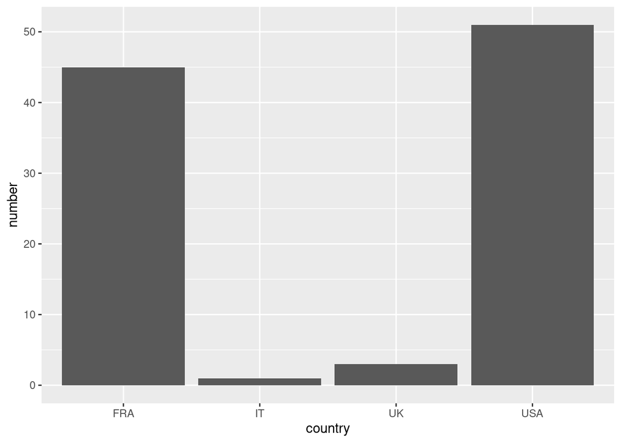

```r
library(ggplot2)
ggplot(boxoffice,
       aes(x = country,
           y = number)) +
  geom_col()
```

**Trier les valeurs par odre croissant + clean graph**

```r
library(forcats)

# On transforme en facteur
factor(boxoffice$country)
```

```
## [1] USA FRA UK  IT
## Levels: FRA IT UK USA
```

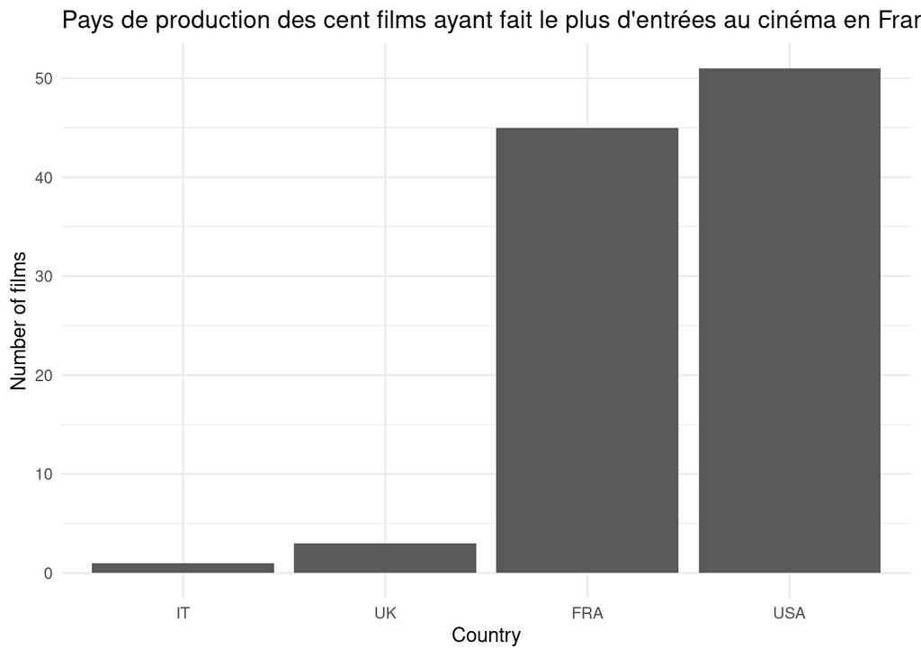

```r
orderedList <- fct_reorder(boxoffice$country, boxoffice$number) # -boxoffice$number => décroissant

ggplot(boxoffice,
       aes(x = orderedList,
           y = number))+
  geom_col() +
  xlab("Country") +
  ylab("Number of films")+
  theme_minimal() +
  ggtitle("Pays de production des cent films ayant fait le plus d'entrées au cinéma en France depuis 1930")
```

## Pingouins

```r
library(palmerpenguins)
penguins_nomissing <- na.omit(penguins) # We want to have data without missing lines
head(penguins_nomissing)
```

```
## # A tibble: 6 × 8
##   species island    bill_length_mm bill_depth_mm flipper_length_mm body_mass_g
##   <fct>   <fct>              <dbl>         <dbl>             <int>       <int>
## 1 Adelie  Torgersen           39.1          18.7               181        3750
## 2 Adelie  Torgersen           39.5          17.4               186        3800
## 3 Adelie  Torgersen           40.3          18                 195        3250
## 4 Adelie  Torgersen           36.7          19.3               193        3450
## 5 Adelie  Torgersen           39.3          20.6               190        3650
## 6 Adelie  Torgersen           38.9          17.8               181        3625
## # ℹ 2 more variables: sex <fct>, year <int>
```

```r
nrow(penguins_nomissing) # connaitre le nombre de ligne dans un tableau
```

```
## [1] 333
```

### **Experience statistique**

- **quelle question tente-t-on de répondre ?**

```
On cherche à determiner le nombre d'individus de chaque espèce de pingouins présente dans l'archipel
```

- **quels sont les *individus* ?**

  Les pingouins
- **quelle est la *population* ? l’*échantillon* ?**

  **La population:** L’ensemble des pingouins de l’archipel

  **L’échantillon:** 333 pingouins de l’archipels
- **quelle est la *variable* ? quelles sont ses *modalités* ?**

  Ici on considérera la variable comme étant l’espece de pingouin.

  Modalité: Chinstrap, gentoo adélie

### Comptage

```r
sum(penguins_nomissing$species == "Adelie")
```

```
## [1] 146
```

```r
sum(penguins_nomissing$species == "Gentoo")
```

```
## [1] 119
```

```r
sum(penguins_nomissing$species == "Chinstrap")
```

```
## [1] 68
```

On a 146 Adelie, 119 Gentoo et 68 Chinstrap

### Diagramme en bar

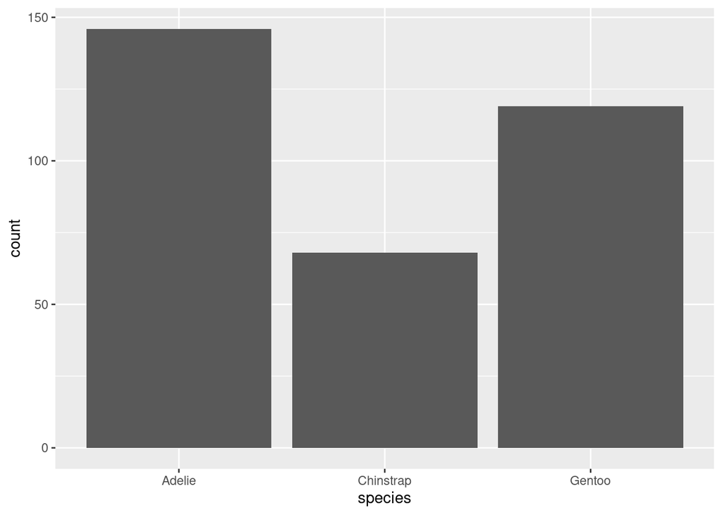

```r
ggplot(penguins_nomissing,
       aes(x = species)) +

  geom_bar()
```

### Nettoyage

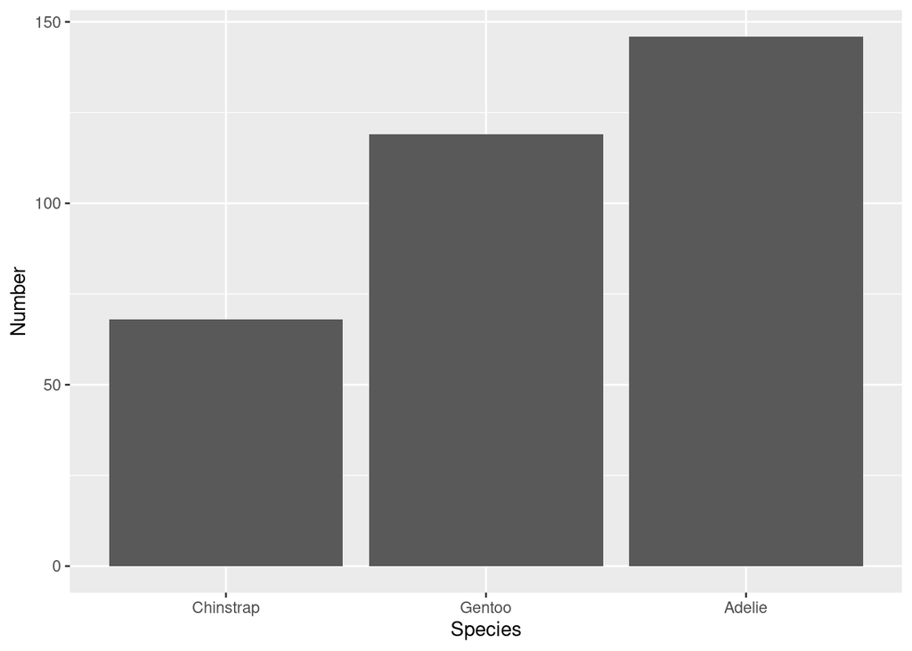

```r
ggplot(penguins_nomissing,
       aes(x = fct_relevel(species, "Chinstrap", "Gentoo", "Adelie"))) +
      xlab("Species") +
  ylab("Number")+
  geom_bar()
```

### Ajout d’information

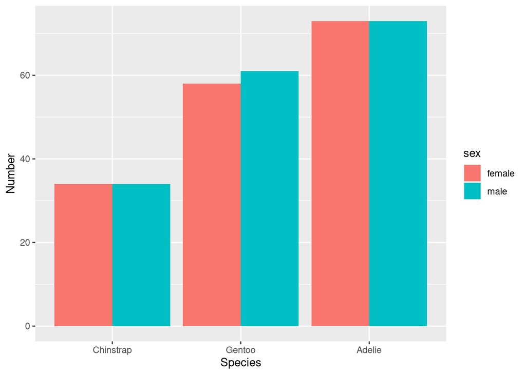

```r
ggplot(penguins_nomissing,
       aes(x = fct_relevel(species, "Chinstrap", "Gentoo", "Adelie"),
           fill = sex)) +
      xlab("Species") +
  ylab("Number")+
  geom_bar(position = "dodge")
```

**Variation**

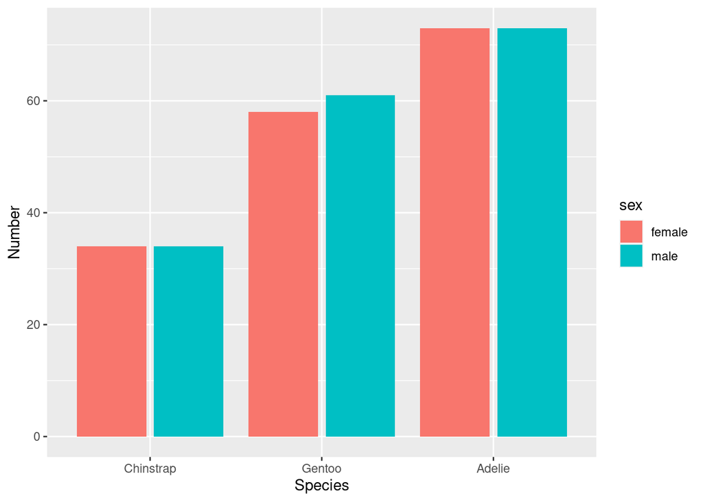

```r
ggplot(penguins_nomissing,
       aes(x = fct_relevel(species, "Chinstrap", "Gentoo", "Adelie"),
           fill = sex)) +
      xlab("Species") +
  ylab("Number")+
  geom_bar(position = "dodge2")
```

## Parlements

```r
library(readxl)
library(here)
```

```r
data <- read_xlsx(here("data", "women_in_parliament-historical_database-1945_to_2018.xlsx"),
                  col_types = c("text", "text", "text",
        "numeric", "text", "text", "numeric",
        "numeric", "numeric", "text"))
data
```

```
## # A tibble: 3,815 × 10
##    Country     Region `Election / Renewal`  Year Month `Chamber Type`
##    <chr>       <chr>  <chr>                <dbl> <chr> <chr>
##  1 Afghanistan ASIA   Yes                   1965 July  Lower
##  2 Afghanistan ASIA   Yes                   1965 July  Upper
##  3 Afghanistan ASIA   Yes                   1969 <NA>  Lower
##  4 Afghanistan ASIA   Yes                   1969 <NA>  Upper
##  5 Afghanistan ASIA   Yes                   1988 <NA>  Lower
##  6 Afghanistan ASIA   Yes                   1988 <NA>  Upper
##  7 Afghanistan ASIA   Yes                   2005 <NA>  Lower
##  8 Afghanistan ASIA   Yes                   2005 <NA>  Upper
##  9 Afghanistan ASIA   Yes                   2010 <NA>  Lower
## 10 Afghanistan ASIA   Yes                   2010 <NA>  Upper
## # ℹ 3,805 more rows
## # ℹ 4 more variables: `Chamber Total Seats` <dbl>, `Total women` <dbl>,
## #   `% Of Women in Chamber` <dbl>, NOTES <chr>
```

### Assemblée constituante française

4eme république: 27 octobre 1946

```r
subsetData <- subset(data, Year==1946 & Country=="France" & NOTES=="Constitutional Assembly")
subsetData
```

```
## # A tibble: 1 × 10
##   Country Region `Election / Renewal`  Year Month `Chamber Type`
##   <chr>   <chr>  <chr>                <dbl> <chr> <chr>
## 1 France  EUR    Yes                   1946 <NA>  Lower
## # ℹ 4 more variables: `Chamber Total Seats` <dbl>, `Total women` <dbl>,
## #   `% Of Women in Chamber` <dbl>, NOTES <chr>
```

```r
percentOfWomen <- subsetData[c("% Of Women in Chamber")] # le pourcentage de femmes

men <- 1 - percentOfWomen
men # pourcentage d'homme
```

```
##   % Of Women in Chamber
## 1             0.9488055
```

### Diagramme en barre

```r
library(ggplot2)
subsetData$homme <- 1 - subsetData$`% Of Women in Chamber`

smallTable <- data.frame(category= c("Women", "Men"),
                         percent = c(subsetData$`% Of Women in Chamber`,subsetData$homme))
smallTable
```

```
##   category    percent
## 1    Women 0.05119454
## 2      Men 0.94880546
```

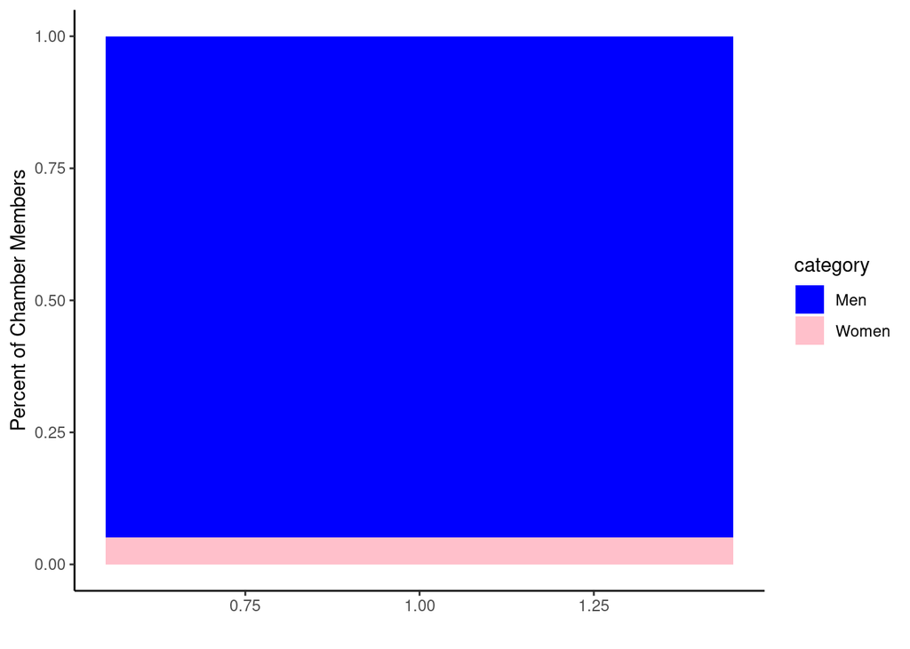

```r
ggplot(smallTable,
       aes(x = 1,
           y = percent,
           fill=category), position = "fill") +
  geom_col(position = "stack") +
  scale_fill_manual(values = c("blue", "pink")) +
  labs(x = "", y = "Percent of Chamber Members") +
  theme_classic()
```

Ici je trouve cela plus pertinent de representer les données das un graph stacké pour bien mettre en exergue la proportion d’homme bien plus importante

### Graph en secteur

[figure not shown]

```r
library(ggplot2)
library(ggforce)

subsetData$homme <- 1 - subsetData$`% Of Women in Chamber`

smallTable <- data.frame(category= c("Women", "Men"),
                         percent = c(subsetData$`% Of Women in Chamber`,subsetData$homme))

pie <- ggplot(smallTable,
               aes(x0 = 0, y0 = 0, r0 = 0, r = 1, start =0, end = 1,
                   amount = percent,
                   fill = fct_relevel(category, "Women", "Men"))) +
  coord_fixed() +
  ggtitle("Proportion de femmes dans l'assemblée constituante \nde la quatrième république Française") +
  geom_arc_bar(stat = "pie", color = "white", size = 0.2) +
  scale_fill_manual(values = c("#FF69B4", "#4169E1")) +
  theme_void() +
  theme(plot.title = element_text(size = 15, hjust = 0.5),
        legend.position = "right",
        legend.text = element_text(size = 14),
        legend.title = element_blank(),
        axis.title = element_blank())

pie
```

**Proportion de femme dans l’assemblée constituante de la cinquième république**

Date: adoptée le 28 septembre 1958, promulguée le 4 octobre 1958

j’ai prit le type de chambre lower, je n’ai pas pu trouver la différence entre lower et upper mais lower avait plus de siège donc je l’ai selectionné

```r
subsetData5eme <- subset(data, Year==1958 & Country=="France" & `Chamber Type`=="Lower")
subsetData5eme
```

```
## # A tibble: 1 × 10
##   Country Region `Election / Renewal`  Year Month `Chamber Type`
##   <chr>   <chr>  <chr>                <dbl> <chr> <chr>
## 1 France  EUR    Yes                   1958 <NA>  Lower
## # ℹ 4 more variables: `Chamber Total Seats` <dbl>, `Total women` <dbl>,
## #   `% Of Women in Chamber` <dbl>, NOTES <chr>
```

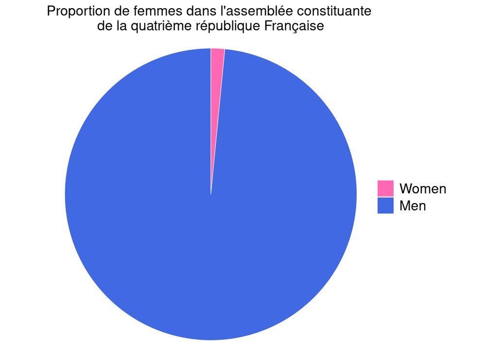

```r
percentOfWomen <- subsetData[c("% Of Women in Chamber")] # le pourcentage de femmes

subsetData5eme$homme <- 1 - subsetData5eme$`% Of Women in Chamber`

smallTable <- data.frame(category= c("Women", "Men"),
                         percent = c(subsetData5eme$`% Of Women in Chamber`,subsetData5eme$homme))

pie <- ggplot(smallTable,
               aes(x0 = 0, y0 = 0, r0 = 0, r = 1,
                   amount = percent,
                   fill = fct_relevel(category, "Women", "Men"))) +
  coord_fixed() +
  ggtitle("Proportion de femmes dans l'assemblée constituante \nde la quatrième république Française") +
  geom_arc_bar(stat = "pie", color = "white", size = 0.2) +
  scale_fill_manual(values = c("#FF69B4", "#4169E1")) +
  theme_void() +
  theme(plot.title = element_text(size = 14, hjust = 0.5),
        legend.position = "right",
        legend.text = element_text(size = 14),
        legend.title = element_blank(),
        axis.title = element_blank())

pie
```

```r
subsetDataColombia <- subset(data,  Country=="Colombia" & `Chamber Type` == "Lower")
subsetDataColombia
```

```
## # A tibble: 16 × 10
##    Country  Region `Election / Renewal`  Year Month `Chamber Type`
##    <chr>    <chr>  <chr>                <dbl> <chr> <chr>
##  1 Colombia AME    Yes                   1966 <NA>  Lower
##  2 Colombia AME    Yes                   1968 <NA>  Lower
##  3 Colombia AME    Yes                   1970 <NA>  Lower
##  4 Colombia AME    Yes                   1974 <NA>  Lower
##  5 Colombia AME    Yes                   1978 <NA>  Lower
##  6 Colombia AME    Yes                   1982 <NA>  Lower
##  7 Colombia AME    Yes                   1986 <NA>  Lower
##  8 Colombia AME    Yes                   1990 <NA>  Lower
##  9 Colombia AME    Yes                   1991 <NA>  Lower
## 10 Colombia AME    Yes                   1994 <NA>  Lower
## 11 Colombia AME    Yes                   1998 <NA>  Lower
## 12 Colombia AME    Yes                   2002 <NA>  Lower
## 13 Colombia AME    Yes                   2006 <NA>  Lower
## 14 Colombia AME    Yes                   2010 <NA>  Lower
## 15 Colombia AME    Yes                   2014 <NA>  Lower
## 16 Colombia AME    Yes                   2018 MARCH Lower
## # ℹ 4 more variables: `Chamber Total Seats` <dbl>, `Total women` <dbl>,
## #   `% Of Women in Chamber` <dbl>, NOTES <chr>
```

### Données

```r
subsetDataColombia$homme <- 1 - subsetDataColombia$`% Of Women in Chamber`

smallTableColombia <- data.frame(
  year = subsetDataColombia$Year,
  category = c(rep("Women", length(subsetDataColombia$`% Of Women in Chamber`)),
               rep("Men", length(subsetDataColombia$homme))),
  percent = c(subsetDataColombia$`% Of Women in Chamber`, subsetDataColombia$homme)
)
```

### Diagramme barre empilées

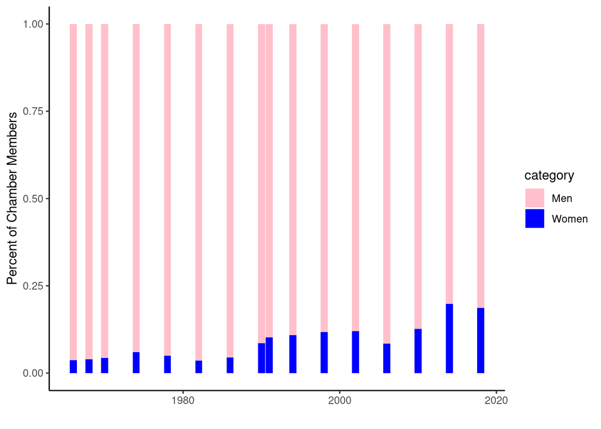

```r
ggplot(smallTableColombia,
       aes(x = year, y = percent, fill = category)) +
  geom_bar(position = "stack", stat = "identity") +
  scale_fill_manual(values = c("pink", "blue")) +
  labs(x = "", y = "Percent of Chamber Members") +
  theme_classic()
```

### Diagramme en secteur

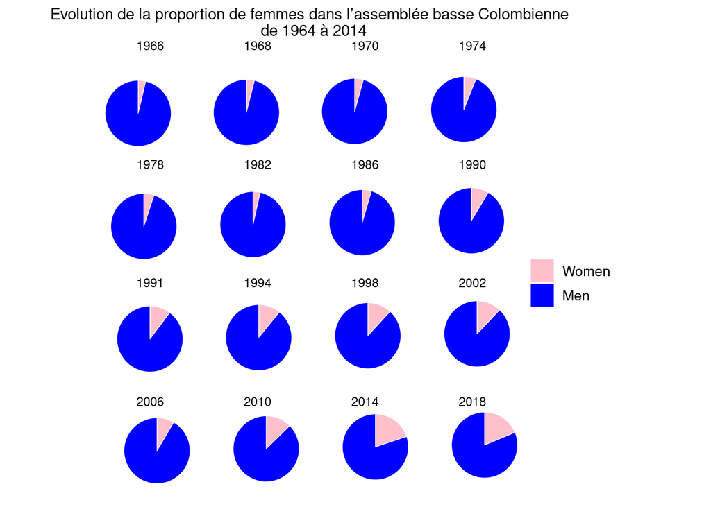

```r
pie <- ggplot(smallTableColombia,
               aes(x0 = year, y0 = year, r0 = 70, r = 0,
                   amount = percent,
                   fill = fct_relevel(category, "Women", "Men"))) +
  coord_fixed() +
  ggtitle("Evolution de la proportion de femmes dans l’assemblée basse Colombienne \n de 1964 à 2014") +
  geom_arc_bar(stat = "pie", color = "white", size = 0.2) +
  scale_fill_manual(values = c("pink", "blue")) +
  theme_void() +
  theme(plot.title = element_text(size = 11, hjust = 0.5),
        legend.position = "right",
        legend.text = element_text(size = 10),
        legend.title = element_blank(),
        axis.title = element_blank()) +
  facet_wrap(~year, ncol = 4)

pie
```

## Autres questions

**Question:** Evolution de la proportion de femmes dans l’assemblée basse Italienne de 1948 à 2008

**Data**

```r
subsetDataItalie <- subset(data, (Year == "1948" | Year == "1976" | Year == "2008") &
                                Country == "Italy" & `Chamber Type` == "Lower"
                         )
subsetDataItalie
```

```
## # A tibble: 3 × 10
##   Country Region `Election / Renewal`  Year Month `Chamber Type`
##   <chr>   <chr>  <chr>                <dbl> <chr> <chr>
## 1 Italy   EUR    Yes                   1948 <NA>  Lower
## 2 Italy   EUR    Yes                   1976 <NA>  Lower
## 3 Italy   EUR    Yes                   2008 <NA>  Lower
## # ℹ 4 more variables: `Chamber Total Seats` <dbl>, `Total women` <dbl>,
## #   `% Of Women in Chamber` <dbl>, NOTES <chr>
```

**Premier graph**

```r
library(ggplot2)

subsetDataItalie$homme <- 1 - subsetDataItalie$`% Of Women in Chamber`

smallDataItalie <- data.frame(
  year = c("1948", "1976", "2008"),
  category = c(rep("Women", length(subsetDataItalie$`% Of Women in Chamber`)),
               rep("Men", length(subsetDataItalie$homme))),
  percent = c(subsetDataItalie$`% Of Women in Chamber`, subsetDataItalie$homme)
)
smallDataItalie
```

```
##   year category    percent
## 1 1948    Women 0.07665505
## 2 1976    Women 0.07460317
## 3 2008    Women 0.21144674
## 4 1948      Men 0.92334495
## 5 1976      Men 0.92539683
## 6 2008      Men 0.78855326
```

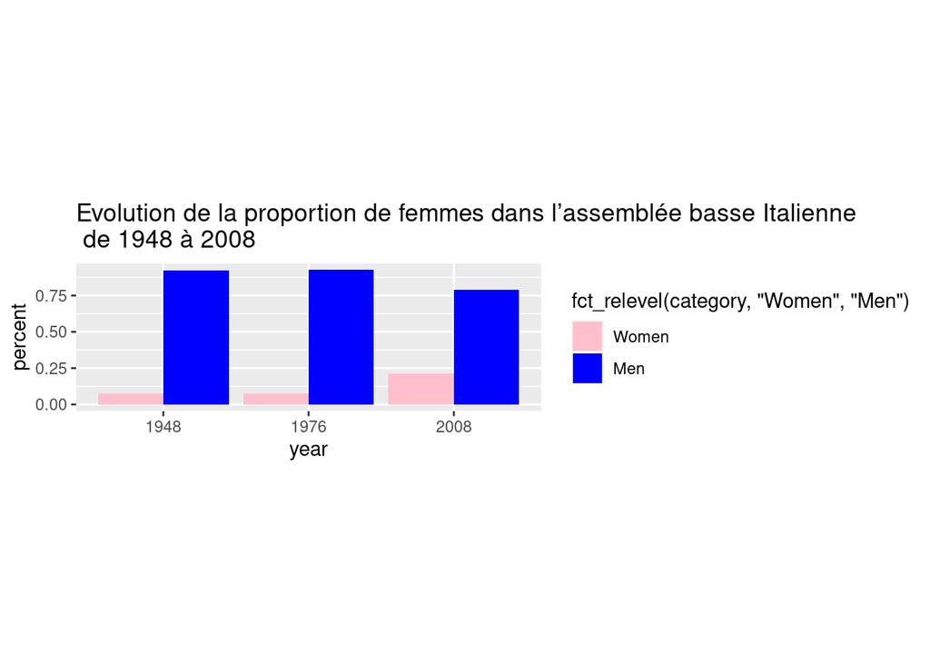

```r
ggplot(smallDataItalie,
       aes(x = year,
           y = percent,
           fill = fct_relevel(category, "Women", "Men"))) +
  coord_fixed() +
  ggtitle("Evolution de la proportion de femmes dans l’assemblée basse Italienne \n de 1948 à 2008") +
  geom_col(position = "dodge") +
  scale_fill_manual(values = c("pink", "blue"))
```

```r
subsetDataItaliePie <- subset(data,
                                Country == "Italy" & `Chamber Type` == "Lower"
                         )
subsetDataItaliePie
```

```
## # A tibble: 19 × 10
##    Country Region `Election / Renewal`  Year Month `Chamber Type`
##    <chr>   <chr>  <chr>                <dbl> <chr> <chr>
##  1 Italy   EUR    Yes                   1948 <NA>  Lower
##  2 Italy   EUR    Yes                   1953 <NA>  Lower
##  3 Italy   EUR    Yes                   1958 <NA>  Lower
##  4 Italy   EUR    Yes                   1963 <NA>  Lower
##  5 Italy   EUR    Yes                   1968 <NA>  Lower
##  6 Italy   EUR    Yes                   1972 <NA>  Lower
##  7 Italy   EUR    Yes                   1976 <NA>  Lower
##  8 Italy   EUR    Yes                   1979 <NA>  Lower
##  9 Italy   EUR    Yes                   1983 <NA>  Lower
## 10 Italy   EUR    Yes                   1987 <NA>  Lower
## 11 Italy   EUR    Yes                   1992 <NA>  Lower
## 12 Italy   EUR    Yes                   1994 <NA>  Lower
## 13 Italy   EUR    Yes                   1996 <NA>  Lower
## 14 Italy   EUR    Yes                   2001 <NA>  Lower
## 15 Italy   EUR    Yes                   2006 <NA>  Lower
## 16 Italy   EUR    Yes                   2008 <NA>  Lower
## 17 Italy   EUR    Yes                   2013 March Lower
## 18 Italy   EUR    Yes                   2013 May   Lower
## 19 Italy   EUR    Yes                   2018 March Lower
## # ℹ 4 more variables: `Chamber Total Seats` <dbl>, `Total women` <dbl>,
## #   `% Of Women in Chamber` <dbl>, NOTES <chr>
```

```r
subsetDataItaliePie$homme <- 1 - subsetDataItaliePie$`% Of Women in Chamber`

smallTableItalie <- data.frame(
  year = subsetDataItaliePie$Year,
  category = c(rep("Women", length(subsetDataItaliePie$`% Of Women in Chamber`)),
               rep("Men", length(subsetDataItaliePie$homme))),
  percent = c(subsetDataItaliePie$`% Of Women in Chamber`, subsetDataItaliePie$homme)
)
smallTableColombia
```

```
##    year category    percent
## 1  1966    Women 0.03684211
## 2  1968    Women 0.03921569
## 3  1970    Women 0.04285714
## 4  1974    Women 0.06030151
## 5  1978    Women 0.05025126
## 6  1982    Women 0.03517588
## 7  1986    Women 0.04522613
## 8  1990    Women 0.08542714
## 9  1991    Women 0.10240964
## 10 1994    Women 0.10843373
## 11 1998    Women 0.11801242
## 12 2002    Women 0.12048193
## 13 2006    Women 0.08433735
## 14 2010    Women 0.12650602
```

[output cut: 18 more lines]

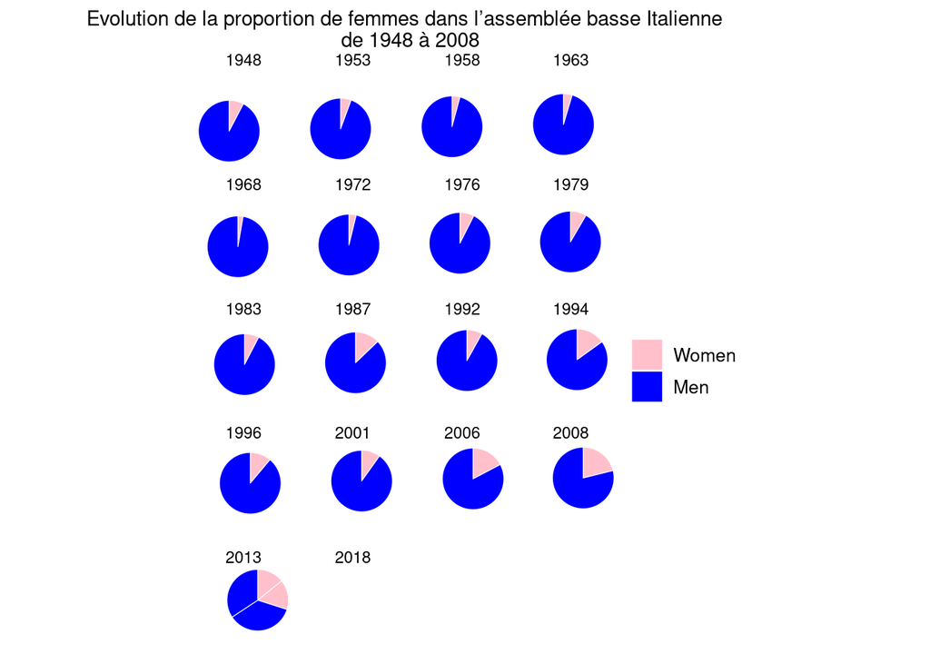

```r
pie <- ggplot(smallTableItalie,
               aes(x0 = year, y0 = year, r0 = 70, r = 0,
                   amount = percent,
                   fill = fct_relevel(category, "Women", "Men"))) +
  coord_fixed() +
  ggtitle("Evolution de la proportion de femmes dans l’assemblée basse Italienne \n de 1948 à 2008") +
  geom_arc_bar(stat = "pie", color = "white", size = 0.2) +
  scale_fill_manual(values = c("pink", "blue")) +
  theme_void() +
  theme(plot.title = element_text(size = 11, hjust = 0.5),
        legend.position = "right",
        legend.text = element_text(size = 10),
        legend.title = element_blank(),
        axis.title = element_blank()) +
  facet_wrap(~year, ncol = 4)

pie
```

**Conclusion**

Dans la première section, j’ai exploré les données en me concentrant sur un pays donné à une année donnée. Ensuite, dans la seconde section, j’ai examiné les données d’un pays donné au fil du temps.

J’ai décidé de poser ma propre question sur les données en utilisant les exemples donnés. J’ai choisi de me demander quelle était la proportion de femmes dans les chambres basses d’Italie de 1948 à 2008. Pour répondre à cette question, j’ai créé un graphique en utilisant les données correspondantes.

Tout d’abord, j’ai essayé de représenter les données sous forme de diagramme en barres. Cependant, le résultat n’était pas satisfaisant, car le graphique ne permettait pas une comparaison claire des proportions de femmes et d’hommes dans les différentes années. J’ai donc décidé de représenter les données sous forme de diagramme circulaire.

En somme, la représentation choisie permet une comparaison facile des proportions de femmes et d’hommes dans les différentes années, permettant ainsi de répondre à la question posée de manière claire et concise